# The Implementations of Basic Algorithms

1. Neural Network Reggresion with neuralnet
2. Support Vector Machines Algorithm
3. Association Mining

## The links for algorithms

[Neural Network-1](https://datascienceplus.com/neuralnet-train-and-test-neural-networks-using-r/)  
[Neural Network-2](https://beckmw.wordpress.com/tag/nnet/)  
[SVM-1](https://cran.r-project.org/web/packages/e1071/vignettes/svmdoc.pdf)  
[SVM-2](https://www.r-bloggers.com/machine-learning-using-support-vector-machines/)  
[SVM-3](http://uc-r.github.io/svm)  
[Association Mining-1](http://r-statistics.co/Association-Mining-With-R.html)  
[Association Mining-2](https://towardsdatascience.com/association-rule-mining-in-r-ddf2d044ae50)

# Neural Network Reggresion

```r
library(neuralnet)
library(knitr)
library(nnet)
library(kableExtra)
library(dplyr)
```

```r
concrete<-read.csv("Concrete_Data.csv")

normalize<-function(x){
  return((x - min(x))/(max(x)-min(x)))
}
DT::datatable(concrete[-6,-7],options=list(pageLength = 5))
```

|  | Cement | Slag | Ash | Water | Superplasticizer | Coarse.Aggregate | Age | CC_strength |
| --- | --- | --- | --- | --- | --- | --- | --- | --- |
| 1 | 540 | 0 | 0 | 162 | 2.5 | 1040 | 28 | 79.99 |
| 2 | 540 | 0 | 0 | 162 | 2.5 | 1055 | 28 | 61.89 |
| 3 | 332.5 | 142.5 | 0 | 228 | 0 | 932 | 270 | 40.27 |
| 4 | 332.5 | 142.5 | 0 | 228 | 0 | 932 | 365 | 41.05 |
| 5 | 198.6 | 132.4 | 0 | 192 | 0 | 978.4 | 360 | 44.3 |
| 7 | 380 | 95 | 0 | 228 | 0 | 932 | 365 | 43.7 |
| 8 | 380 | 95 | 0 | 228 | 0 | 932 | 28 | 36.45 |
| 9 | 266 | 114 | 0 | 228 | 0 | 932 | 28 | 45.85 |
| 10 | 475 | 0 | 0 | 228 | 0 | 932 | 28 | 39.29 |
| 11 | 198.6 | 132.4 | 0 | 192 | 0 | 978.4 | 90 | 38.07 |

[output cut: 1019 more lines]

```r
concrete_norm<-as.data.frame(lapply(concrete,normalize))
summary(concrete_norm$CC_strength)
```

```
##    Min. 1st Qu.  Median    Mean 3rd Qu.    Max.
##  0.0000  0.2664  0.4001  0.4172  0.5457  1.0000
```

```r
n = nrow(concrete_norm)
trainIndex = sample(1:n, size = round(0.7*n), replace=FALSE)
train = concrete_norm[trainIndex ,]
test = concrete_norm[-trainIndex ,]
```

> model<-neuralnet(target~ predictors,data=data,hidden=n)  
> hidden is the number of neurons in the hidden layer.  
> predictions<-compute(model,test) -> predictions$net.result function gives the results of model.

```r
concrete_model<-neuralnet(CC_strength~., data=train,hidden = 10)

predicted<-predict(concrete_model,test[1:8])
cor(predicted,test$CC_strength)
```

```
##           [,1]
## [1,] 0.9470916
```

```r
nn_model<-nnet(CC_strength~., data=train, size=10, decay=5e-5, maxit=1000)
```

```r
predicted_nn<-predict(nn_model,test[1:8])
cor(predicted_nn,test$CC_strength)
```

```
##           [,1]
## [1,] 0.9420967
```

# Support Vector Machines Algorithm on Letter Prediction

```r
library(kernlab)
library(arules)
```

ksvm(x, y = NULL, scaled = TRUE, type = NULL, kernel =“rbfdot”, kpar = “automatic”, C = 1, nu = 0.2, epsilon = 0.1, prob.model = FALSE, class.weights = NULL, cross = 0, fit = TRUE, cache = 40, tol = 0.001, shrinking = TRUE, …, subset, na.action = na.omit)

predictions<-predict(model,test,type=“response” or “probabilities” )

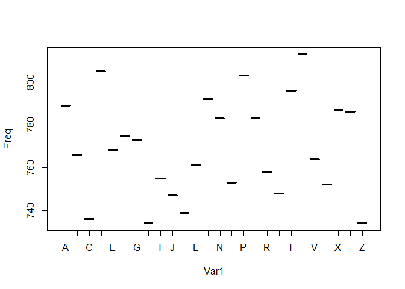

```r
letters<-read.csv("letterdata.csv")
plot(as.data.frame(table(letters$letter)))
```

```r
n = nrow(letters)
trainIndex = sample(1:n, size = round(0.7*n), replace=FALSE)
letters_train = letters[trainIndex ,]
letters_test = letters[-trainIndex ,]
```

```r
DT::datatable(letters[1:6])
```

|  | letter | x.box | y.box | width | high | onpix |
| --- | --- | --- | --- | --- | --- | --- |
| 1 | T | 2 | 8 | 3 | 5 | 1 |
| 2 | I | 5 | 12 | 3 | 7 | 2 |
| 3 | D | 4 | 11 | 6 | 8 | 6 |
| 4 | N | 7 | 11 | 6 | 6 | 3 |
| 5 | G | 2 | 1 | 3 | 1 | 1 |
| 6 | S | 4 | 11 | 5 | 8 | 3 |
| 7 | B | 4 | 2 | 5 | 4 | 4 |
| 8 | A | 1 | 1 | 3 | 2 | 1 |
| 9 | J | 2 | 2 | 4 | 4 | 2 |
| 10 | M | 11 | 15 | 13 | 9 | 7 |

[output cut: 19990 more lines]

```r
letter_classifier<-ksvm(letter~.,data=letters_train,kernel="vanilladot")
letter_predictions<-predict(letter_classifier,letters_test)
head(letter_predictions)
```

```
## [1] G S X G C S
## Levels: A B C D E F G H I J K L M N O P Q R S T U V W X Y Z
```

```r
table(letter_predictions,letters_test$letter)
```

```
##
## letter_predictions   A   B   C   D   E   F   G   H   I   J   K   L   M   N
##                  A 208   3   0   0   0   0   0   0   0   5   0   0   2   0
##                  B   1 199   0   8   0   1   2   4   2   0   0   1   4   0
##                  C   0   0 207   0   1   0  11   2   1   0   3   1   0   0
##                  D   0   3   0 226   0   1   3  16   3   1   4   2   0   3
##                  E   0   0   5   0 179   0   0   1   1   0   2   6   0   0
##                  F   0   1   2   1   3 198   1   4   8   0   0   0   0   0
##                  G   0   1   2   1  18   5 205   4   0   0   1   5   0   0
##                  H   0   5   0   3   0   0   1 135   0   1   2   1   5  14
##                  I   0   1   0   0   0   1   0   1 205  11   0   0   0   0
##                  J   0   0   0   0   0   0   1   2   7 181   0   0   0   0
##                  K   2   1   4   1   0   0   7   8   0   0 181   2   0   1
##                  L   1   0   2   0   1   0   3   0   1   0   4 202   0   0
##                  M   1   0   1   0   0   0   1   1   0   0   0   0 217   1
##                  N   0   1   0   3   0   1   0   0   0   2   0   0   1 234
##                  O   1   0   0   0   0   0   3   6   1   1   0   0   1   3
##                  P   0   0   0   2   0   6   1   0   0   0   0   0   0   1
##                  Q   0   0   0   0   6   0   4   3   0   0   1   4   0   0
##                  R   0  11   0   3   3   0   3  13   0   1  14   0   4   2
##                  S   0   1   0   0   4   1   1   0   3   5   0   2   0   0
##                  T   0   0   0   1   8   6   0   0   0   0   0   1   0   0
##                  U   0   0   1   3   0   1   1   6   0   0   0   0   9   1
##                  V   0   1   0   0   0   0   4   0   0   0   0   0   0   0
##                  W   0   0   0   0   0   0   2   0   0   0   1   0   2   1
##                  X   0   1   0   0   0   0   1   1   1   0   7   3   0   0
##                  Y   1   0   0   0   0   0   0   0   0   0   0   0   0   0
##                  Z   0   0   0   0   3   0   0   0   1   6   0   0   0   0
##
## letter_predictions   O   P   Q   R   S   T   U   V   W   X   Y   Z
##                  A   7   0   3   2   0   1   0   3   0   0   0   3
##                  B   0   1   2   7   7   0   0   2   0   3   0   1
##                  C   3   0   1   0   0   0   2   0   0   0   0   0
##                  D   7   3   2   3   0   0   1   0   0   2   1   0
##                  E   0   0   6   0  13   3   0   0   0   8   0   3
##                  F   0  13   0   0  11   4   0   0   0   1   3   0
##                  G   2   9   8   2  11   3   1   2   2   2   0   0
##                  H  19   0   0   5   0   2   2   9   3   0   1   0
##                  I   0   0   0   0   3   0   0   0   0   5   0   1
##                  J   0   0   0   0   1   0   0   0   0   5   0   7
##                  K   0   1   0  11   0   1   4   0   0   3   0   0
##                  L   0   0   2   0   4   0   0   0   0   5   0   0
##                  M   0   0   0   0   0   0   0   1   3   0   0   0
##                  N   0   0   0   3   0   0   1   0   0   0   0   0
##                  O 180   3   5   1   0   0   1   0   4   0   0   0
##                  P   2 217   2   0   0   0   0   1   0   0   1   0
##                  Q   3   1 187   0   9   0   0   0   0   1   5   3
##                  R   1   0   0 182   0   0   0   2   0   2   0   0
##                  S   0   0   8   0 170   3   0   0   0   0   1  16
##                  T   0   1   0   1   2 205   0   0   0   3  11   2
##                  U   2   0   0   0   0   2 209   0   1   2   1   0
##                  V   0   1   0   1   0   0   0 214   0   0   1   0
##                  W   6   0   1   0   0   0   0   5 193   0   0   0
##                  X   0   0   0   1   3   1   0   0   0 180   0   0
##                  Y   0   3   1   0   0   2   0   7   0   1 216   0
##                  Z   0   0   0   0  16   3   0   0   0   1   0 181
```

```r
correctness<-letter_predictions==letters_test$letter
table(correctness)
```

```
## correctness
## FALSE  TRUE
##   889  5111
```

```r
prop.table(table(correctness))
```

```
## correctness
##     FALSE      TRUE
## 0.1481667 0.8518333
```

```r
letter_classifier_rbf<-ksvm(letter~. ,data=letters_train,kernel="rbfdot")
letter_predictions_rbf<-predict(letter_classifier_rbf,letters_test)
correctness_rbf<-letter_predictions_rbf==letters_test$letter
prop.table(table(correctness_rbf))
```

```
## correctness_rbf
##      FALSE       TRUE
## 0.07133333 0.92866667
```

# Association Mining

```r
groceries<-read.transactions("groceries.csv",sep=",")

summary(groceries)
```

```
## transactions as itemMatrix in sparse format with
##  9835 rows (elements/itemsets/transactions) and
##  169 columns (items) and a density of 0.02609146
##
## most frequent items:
##       whole milk other vegetables       rolls/buns             soda
##             2513             1903             1809             1715
##           yogurt          (Other)
##             1372            34055
##
## element (itemset/transaction) length distribution:
## sizes
##    1    2    3    4    5    6    7    8    9   10   11   12   13   14   15
## 2159 1643 1299 1005  855  645  545  438  350  246  182  117   78   77   55
##   16   17   18   19   20   21   22   23   24   26   27   28   29   32
##   46   29   14   14    9   11    4    6    1    1    1    1    3    1
##
##    Min. 1st Qu.  Median    Mean 3rd Qu.    Max.
##   1.000   2.000   3.000   4.409   6.000  32.000
##
## includes extended item information - examples:
##             labels
## 1 abrasive cleaner
## 2 artif. sweetener
## 3   baby cosmetics
```

```r
inspect(groceries[1:10])
```

```
##      items
## [1]  {citrus fruit,
##       margarine,
##       ready soups,
##       semi-finished bread}
## [2]  {coffee,
##       tropical fruit,
##       yogurt}
## [3]  {whole milk}
## [4]  {cream cheese,
##       meat spreads,
##       pip fruit,
##       yogurt}
## [5]  {condensed milk,
##       long life bakery product,
##       other vegetables,
##       whole milk}
## [6]  {abrasive cleaner,
##       butter,
##       rice,
##       whole milk,
##       yogurt}
## [7]  {rolls/buns}
## [8]  {bottled beer,
##       liquor (appetizer),
##       other vegetables,
##       rolls/buns,
##       UHT-milk}
## [9]  {potted plants}
## [10] {cereals,
##       whole milk}
```

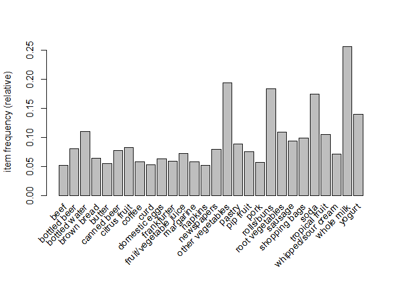

```r
itemFrequencyPlot(groceries,support=0.05)
```

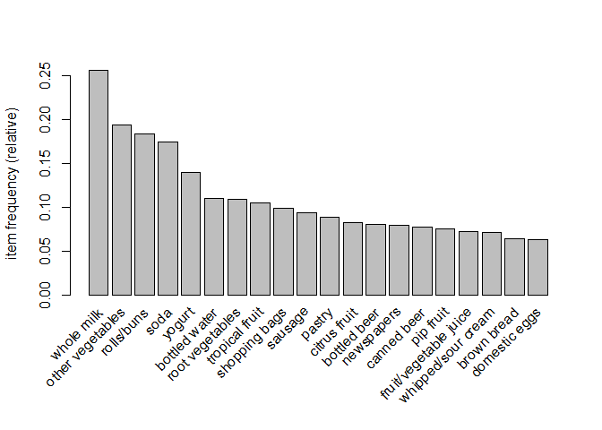

```r
itemFrequencyPlot(groceries,topN=20)
```

```r
apriori(groceries)
```

```
## Apriori
##
## Parameter specification:
##  confidence minval smax arem  aval originalSupport maxtime support minlen
##         0.8    0.1    1 none FALSE            TRUE       5     0.1      1
##  maxlen target   ext
##      10  rules FALSE
##
## Algorithmic control:
##  filter tree heap memopt load sort verbose
##     0.1 TRUE TRUE  FALSE TRUE    2    TRUE
##
## Absolute minimum support count: 983
##
## set item appearances ...[0 item(s)] done [0.00s].
## set transactions ...[169 item(s), 9835 transaction(s)] done [0.00s].
## sorting and recoding items ... [8 item(s)] done [0.00s].
## creating transaction tree ... done [0.00s].
## checking subsets of size 1 2 done [0.00s].
## writing ... [0 rule(s)] done [0.00s].
## creating S4 object  ... done [0.00s].
```

```
## set of 0 rules
```

```r
groceryrules<-apriori(groceries,parameter = list(support=0.006,confidence=0.25,minlen=2))
```

```
## Apriori
##
## Parameter specification:
##  confidence minval smax arem  aval originalSupport maxtime support minlen
##        0.25    0.1    1 none FALSE            TRUE       5   0.006      2
##  maxlen target   ext
##      10  rules FALSE
##
## Algorithmic control:
##  filter tree heap memopt load sort verbose
##     0.1 TRUE TRUE  FALSE TRUE    2    TRUE
##
## Absolute minimum support count: 59
##
## set item appearances ...[0 item(s)] done [0.00s].
## set transactions ...[169 item(s), 9835 transaction(s)] done [0.00s].
## sorting and recoding items ... [109 item(s)] done [0.00s].
## creating transaction tree ... done [0.00s].
## checking subsets of size 1 2 3 4 done [0.00s].
## writing ... [463 rule(s)] done [0.00s].
## creating S4 object  ... done [0.00s].
```

```r
#summary(groceryrules)
inspect(groceryrules[1:3])
```

```
##     lhs                rhs               support     confidence lift
## [1] {potted plants} => {whole milk}      0.006914082 0.4000000  1.565460
## [2] {pasta}         => {whole milk}      0.006100661 0.4054054  1.586614
## [3] {herbs}         => {root vegetables} 0.007015760 0.4312500  3.956477
##     count
## [1] 68
## [2] 60
## [3] 69
```

### The LHS is the condition that needs to be met in order to trigger the rule, and the RHS is the expected result of meeting that condition.

### The lift values tells about us how much more likely a customer is to buy product relative to the average customer,given that he or she bought another product.

```r
inspect(sort(groceryrules,by="lift")[1:5])
```

```
##     lhs                   rhs                      support confidence     lift count
## [1] {herbs}            => {root vegetables}    0.007015760  0.4312500 3.956477    69
## [2] {berries}          => {whipped/sour cream} 0.009049314  0.2721713 3.796886    89
## [3] {other vegetables,
##      tropical fruit,
##      whole milk}       => {root vegetables}    0.007015760  0.4107143 3.768074    69
## [4] {beef,
##      other vegetables} => {root vegetables}    0.007930859  0.4020619 3.688692    78
## [5] {other vegetables,
##      tropical fruit}   => {pip fruit}          0.009456024  0.2634561 3.482649    93
```

```r
berryrules<-subset(groceryrules,items %in% "berries")
inspect(berryrules)
```

```
##     lhs          rhs                  support     confidence lift
## [1] {berries} => {whipped/sour cream} 0.009049314 0.2721713  3.796886
## [2] {berries} => {yogurt}             0.010574479 0.3180428  2.279848
## [3] {berries} => {other vegetables}   0.010269446 0.3088685  1.596280
## [4] {berries} => {whole milk}         0.011794611 0.3547401  1.388328
##     count
## [1]  89
## [2] 104
## [3] 101
## [4] 116
```

```r
#write(groceryrules,file="groceryrules.csv",sep=",",quote=TRUE,row.names=TRUE)
```